# Modelling Temporal Uncertainty

28 august 2020

### Intro

#### List example pithouse data (Crema & Kobayashi)

```r
load(file="c:/R/AUArts/lists/data/res.RData")
```

```r
is(res)
```

```
## [1] "list"   "vector"
```

```r
length(res)
```

```
## [1] 5
```

We check again object’s structure

```r
str(res)
```

```
## List of 5
##  $ Nagano   :'data.frame':   50 obs. of  4 variables:
##   ..$ st    : Factor w/ 29 levels "B2","B5","C1",..: 18 19 20 19 21 22 22 23 24 25 ...
##   ..$ en    : Factor w/ 30 levels "B2","B5","B6",..: 19 20 21 21 22 23 24 24 25 26 ...
##   ..$ counts: int [1:50] 2 7 13 1 4 34 5 82 13 36 ...
##   ..$ pref  : chr [1:50] "Nagano" "Nagano" "Nagano" "Nagano" ...
##  $ Kanagawa :'data.frame':   41 obs. of  4 variables:
##   ..$ st    : Factor w/ 26 levels "B1","B3","C1",..: 16 17 18 19 16 20 21 22 23 24 ...
##   ..$ en    : Factor w/ 25 levels "B3","C11","C12",..: 14 15 16 17 18 19 19 20 21 22 ...
##   ..$ counts: int [1:41] 49 1 5 1 5 2 4 12 17 31 ...
##   ..$ pref  : chr [1:41] "Kanagawa" "Kanagawa" "Kanagawa" "Kanagawa" ...
##  $ Tokyo    :'data.frame':   37 obs. of  4 variables:
##   ..$ st    : Factor w/ 26 levels "B1","B2","B3",..: 15 16 17 18 19 17 16 20 21 22 ...
##   ..$ en    : Factor w/ 26 levels "B1","B2","B3",..: 14 15 16 17 18 18 19 20 21 22 ...
##   ..$ counts: int [1:37] 2 67 14 3 1 11 32 15 11 7 ...
##   ..$ pref  : chr [1:37] "Tokyo" "Tokyo" "Tokyo" "Tokyo" ...
##  $ Saitama  :'data.frame':   40 obs. of  4 variables:
##   ..$ st    : Factor w/ 27 levels "B1","B5","C1",..: 16 17 18 19 18 20 21 22 23 24 ...
##   ..$ en    : Factor w/ 27 levels "B1","B2","B6",..: 16 17 18 19 19 20 21 22 23 24 ...
##   ..$ counts: int [1:40] 1 9 25 3 4 55 54 132 163 45 ...
##   ..$ pref  : chr [1:40] "Saitama" "Saitama" "Saitama" "Saitama" ...
##  $ Yamanashi:'data.frame':   24 obs. of  4 variables:
##   ..$ st    : Factor w/ 21 levels "B1","B2","B4",..: 16 17 18 19 20 21 4 9 10 11 ...
##   ..$ en    : Factor w/ 21 levels "B2","B3","B5",..: 16 17 18 19 20 21 4 9 10 11 ...
##   ..$ counts: int [1:24] 4 38 1 15 47 7 28 10 30 34 ...
##   ..$ pref  : chr [1:24] "Yamanashi" "Yamanashi" "Yamanashi" "Yamanashi" ...
```

Hence, the dataset in object `res` is made of five named components with data frames (where as before names in each component are given after the meta-character `$`).

We can access the names with `attr()` function.

```r
attr(res, "names")
```

```
## [1] "Nagano"    "Kanagawa"  "Tokyo"     "Saitama"   "Yamanashi"
```

Class of the object’s first component corresponding to Nagano prefecture.

```r
is(res[[1]])
```

```
## [1] "data.frame" "list"       "oldClass"   "vector"
```

Since we know that the first component is a data frame, we get the variables from the column names.

```r
colnames(res[[1]])
```

```
## [1] "st"     "en"     "counts" "pref"
```

### Plot counts

A graphical representation of the pithouse counts in Nagano prefecture is given as time series

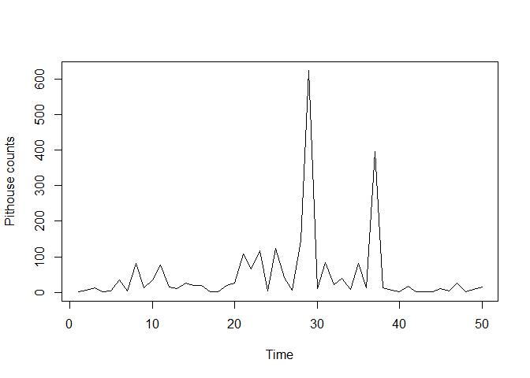

```r
plot(ts(res[[1]][,3]), ylab="Pithouse counts")
```

### Probability of existence

The probability of existence *p*[*t_i*] of an event *e* in a range of time **OMEGA** is the probabilty distribution

*p*[*t_i*] = **delta** *t_i* / **delta** **tau**

where **tau** is the time span of existence, **delta** is for the duration of a given portion of time *t_i* or of **tau**.

To compute *p*[*t_i*], Crema (p. 447) takes the following example:

```
350 ---- 300 ---- 250
     t1       t2

     342 ---- 288
         tau
```

(years are BC)

Hence, **delta** **tau** in this case is 54.

#### Temporal resolution

Temporal resolution **phi symbol** refers to the duration of time blocks. When **phi symbol** is fixed then we have *aoristic analysis*.

To retrieve the minimum probability *P*[**phi symbol**_**alpha**] for the boundaries of the first and last time-blocks, we define **phi symbol**_**alpha** =1 where

**phi**_**alpha** / **delta**_**tau** = 1/54 = *P*[**phi**_**alpha**] = .018 (approx)

Hence, the probability of existence for *t_1*

*P*[*t_1*] = *P*[**phi**_**alpha**] · 42

i.e. 342 - 300

*P*[*t_1*] = .018 · 42 = .78

The probability of existence for for *t_2*

*P*[*t_2*] = *P*[**phi**_**alpha**] · 12

i.e. 300 - 288

*P*[*t_1*] = .018 · 12 = .22

Etc.

#### But

*Assumption*: Any equally long portion of time within the time span **tau** has the same probability of existence. Plus others…

### Aoristic sum

A proxy for evaluating change in the total counts of events across time is the *aoristic sum*, which is the sum of probabilities for each time block.

The aoristic sum is computed accross events for a single portion of time *t_i*.

```
    t1  t2  t3
     ^   ^   ^
a    |   |   |
b    |   |   |
c    |   |   |
     ^   ^   ^
     aoristic
       sums
```

#### But

- uncertainty is embedded in the results
- provides a broad likelihood of process intensity for single time blocks
- unable to provide probabilistic description when two or more time-blocks are directly compared
- more..?

### Rate of change

This refers to transition probabilities like increase/stability/decrease.

Rate of chage = (*e* *t_i*+1 - *e* *t_i*) / **phi symbol**

### Monte Carlo methods

*Monte Carlo* refers to the method of generating random numbers from a certain distribution, and Crema proposes a Monte Carlo solution to overcome the problems of the aoristic sum.

For archaeological applications, Monte Carlo methods consists on creating artificial “potential” time series within the boundary of existence of **tau**, and then assessing the likelihood of the variable’s character state over time.

Each result has a *location* for the mean, and a *scale* for the standard deviation.

#### Bayesian analysis

A *Markov chain* is a sequence of numbers where each number is dependent on the previous number in the sequence.

The term *Markov chain Monte Carlo* (MCMC) refers to algorithms that serves to represent the posterior distribution, which inherently reveals the uncertainty of the parameter estimates. Examples are

- Metropolis-Hastings
- Gibbs
- Importance/rejection sampling (related).

*Proposal* distributions: trapezoidal, normal or gaussian, uniform.